# FSB Student Success Dashboard 2024

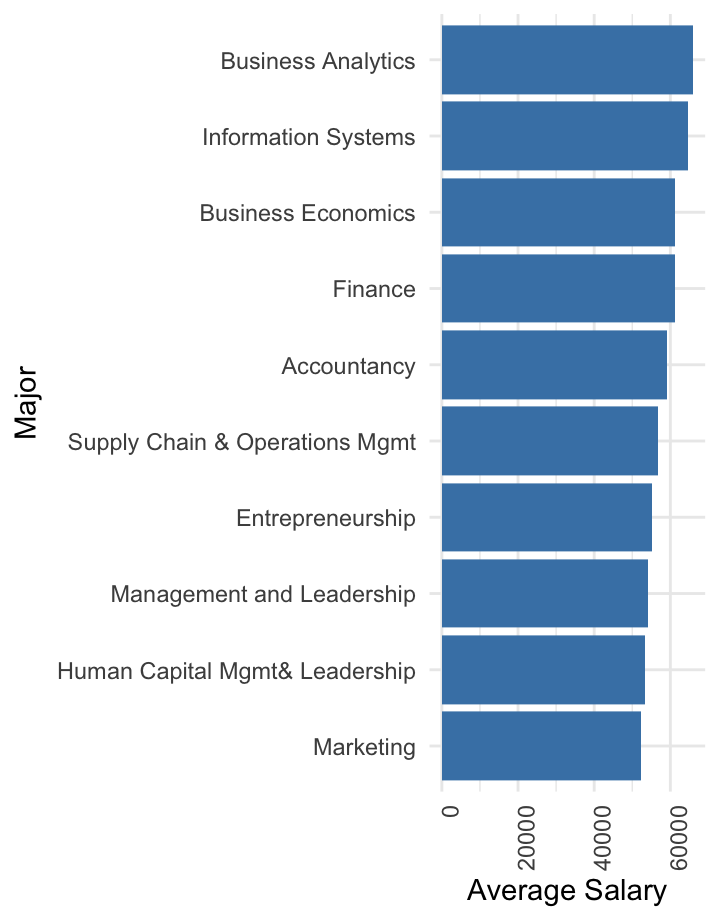

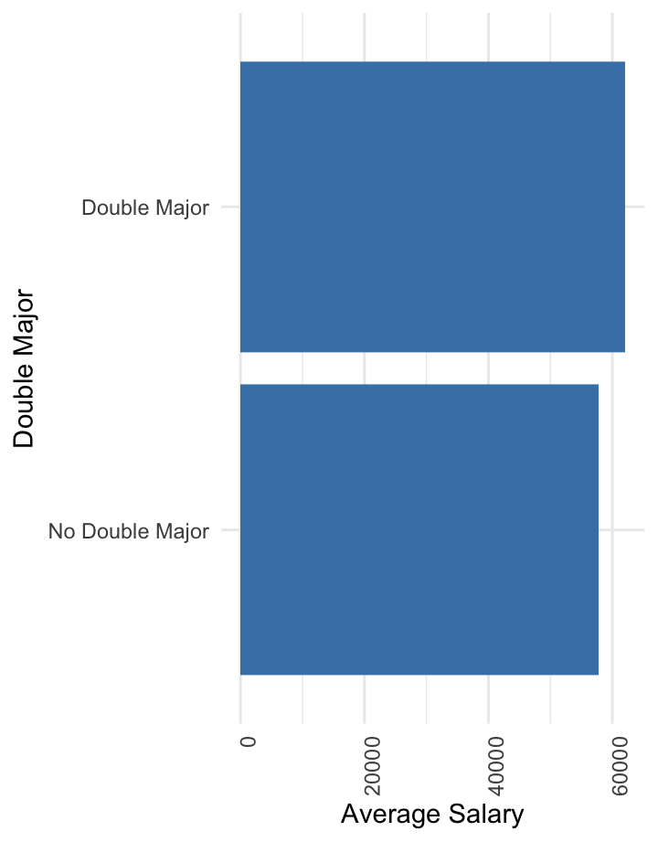

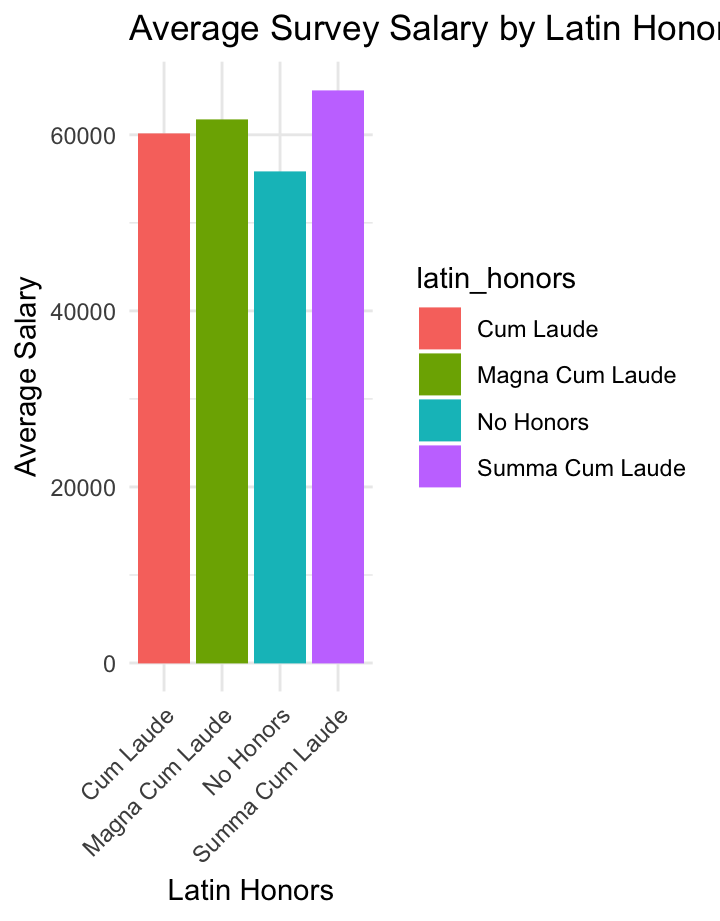

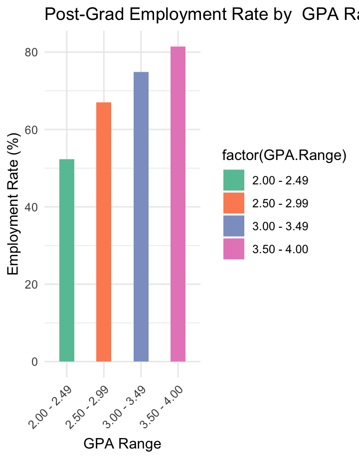

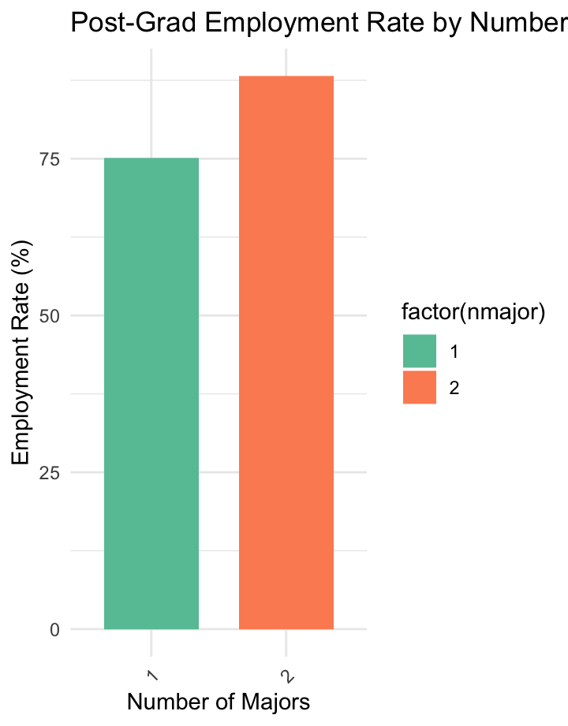

# Question Overview

#### Questions

In this analysis, we aim to explore several key questions using data from FSB (Farmer School of Business) graduates. First, we will break post-graduation salaries of FSB graduates down by major to understand how salaries vary across different fields of study within FSB. Additionally, we will examine the percentage of graduates within each GPA Range who receive job offers immediately after college, offering a view into employment rates by performance.

Beyond major-specific salary and employment data, we will investigate the impact of academic honors on starting salary, determining whether being in an honors program leads to a significant salary premium upon graduation. Finally, we will analyze whether students who pursue a double major have higher starting salaries compared to those who graduate with only one major. This comprehensive analysis will help illuminate the factors that influence starting salary and employment outcomes for FSB graduates, including field of study, academic achievements, and breadth of educational background (single vs. double majors).

# Salary Overview

Overview of Salary Expectations broken down by Various Predictors

## row

### Comparative Salary by Major

We will further break down post-graduation salaries of FSB graduates by major to understand how salaries vary across different fields of study within FSB.

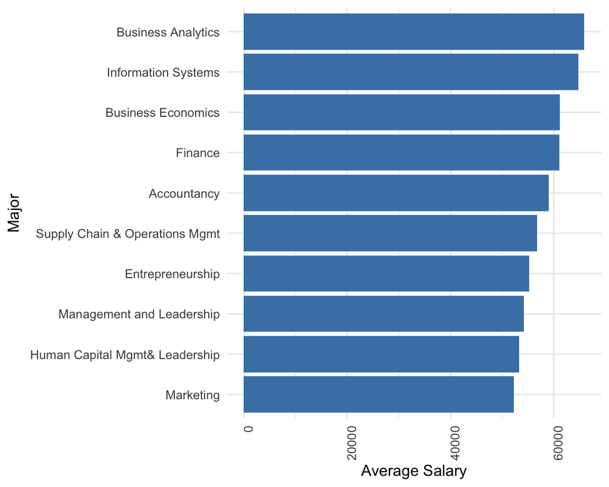

### Comparative Salary by Double Major

Lastly, we will analyze whether students who pursue a double major have higher starting salaries compared to those who graduate with only one major.

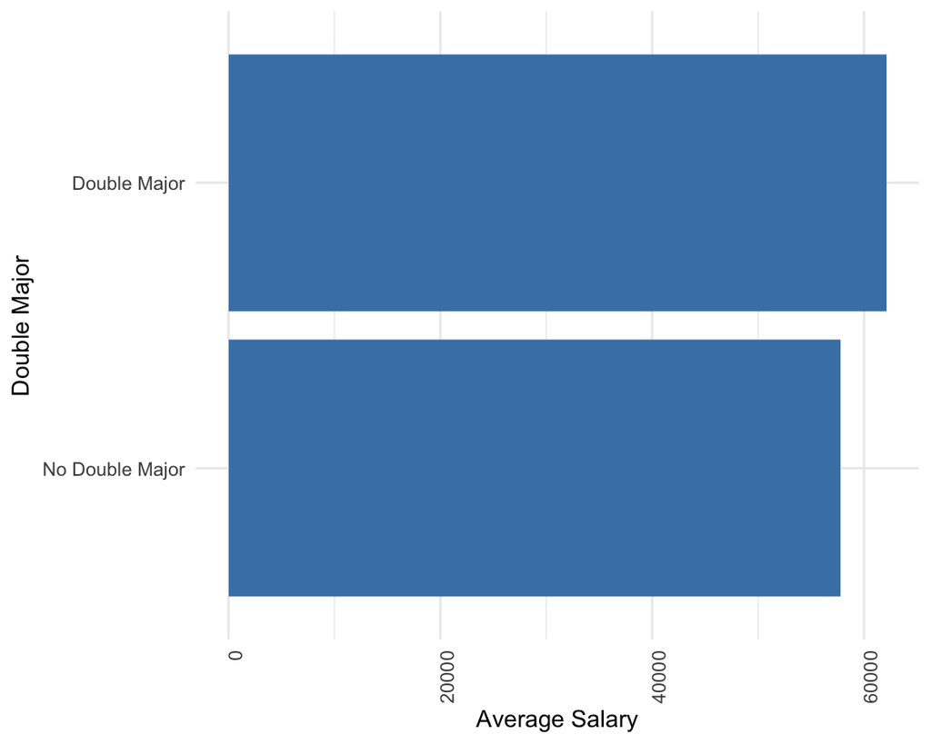

### Salary by Honors Placement

Beyond major-specific salary and employment data, we will investigate the impact of academic honors on starting salary, determining whether being in an honors program leads to a significant salary premium upon graduation.

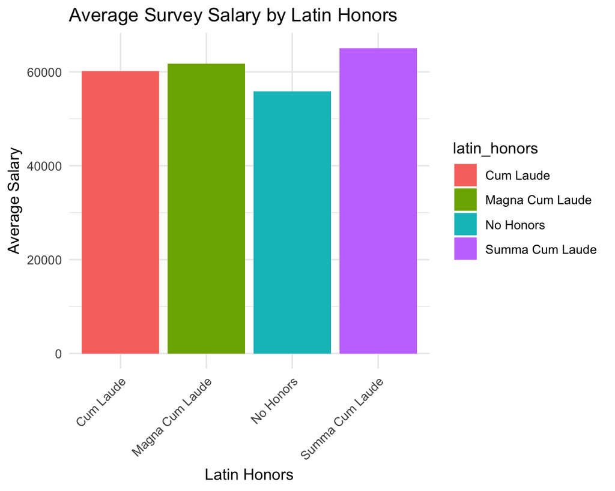

# Post Graduation Employment

## row

### Post-Grad Employment Rate by GPA Range

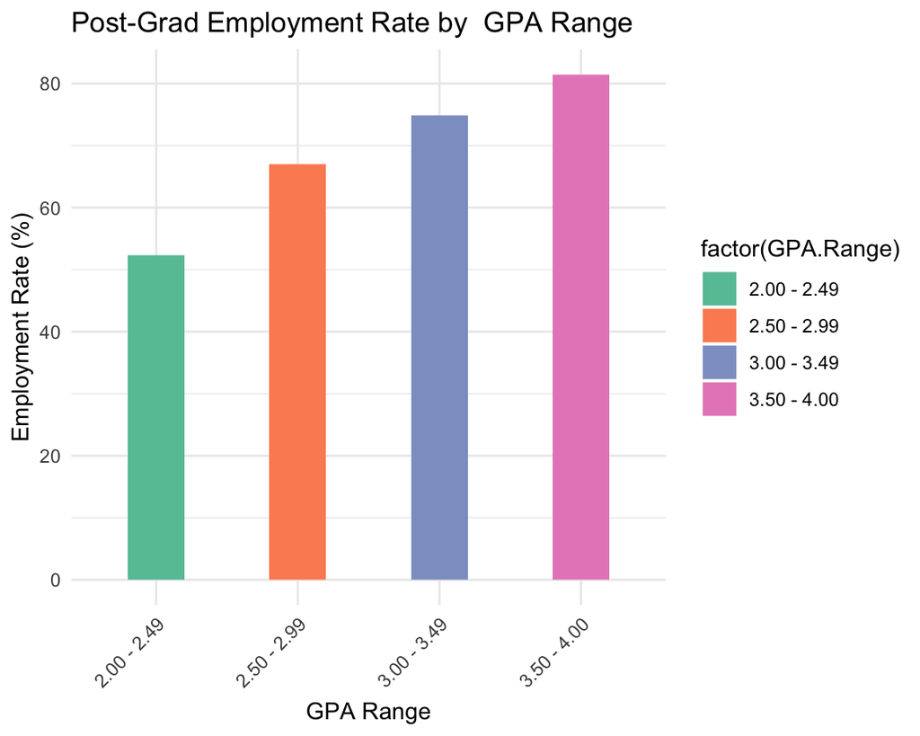

### Post-Grad Employment Rate by Number of Majors

Lastly, we will analyze the percentage of graduates who secured job offers immediately after college, comparing those who pursued a single major to those who pursued double majors.

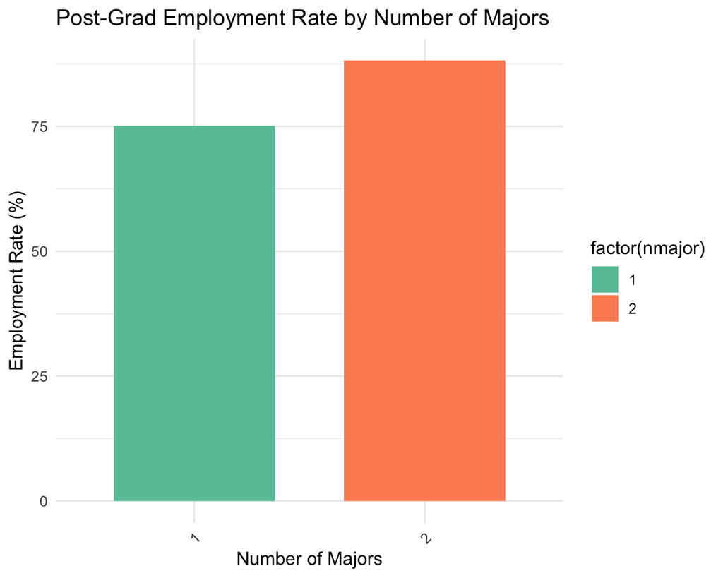